# Ensemble Techniques - Graded Project

```
                            -Meghanadh Bheema
```

## Steps

1. Install the necessary libraries and read the provided dataset. (1 point)
2. EDA and Preprocessing (27 points) a. Check the info and summary statistics of the dataset. List out the columns that need to be worked upon for model building. (2 points) b. Check if there are any duplicate entries for the apps (1 point) c. Check if there are any wrong values in the ‘Category’ column and impute them with relevant values. (2 points) d. Which category has the highest number of apps? (2 points) e. Check the distribution of rating column and convert ratings into two categories and save it in the data frame as ‘Rating_cat’ ( high = +>3.5 and remaining as low) (2 points) f. Convert the ‘Review’ column to a numerical column and impute invalid values if there are any. (1 point) g. Name the top 5 apps which have the highest number of reviews and their genre? (1 point)
3. Prepare data for modeling. (2 points) a. Segregate dependent variable and independent features into two separate variables and split the data into train and test set [ Use 70:30 split ]
4. Build a classifier model to predict the rating category (Rating_cat - high or low) using the following algorithm and make predictions on the test data. Evaluate the model and report your results. (16 points - 4 points each) a. Decision Tree Classifier b. Random Forest model c. Gradient Boosting model d. Stacking model
5. Check the importance of different features by using model.feature_importances_function in Python ( 2 points)
6. Comment on your results and findings from the above analysis. What can you infer about how to make a highly rated mobile App from this project?
7. Further exploration (Optional- non-graded) a. See if you can utilize any of these columns to improve the prediction - Content Rating, Genre, Last updated, Current Ver, and Android Ver b. Fine-tune the models by trying out a different set of hyperparameters c. Try to balance the classes to get better precision for the minority class.

## Install the necessary libraries

```python
import warnings
warnings.filterwarnings("ignore")
```

```python
import numpy as np
import re
import pandas as pd
import scipy.stats as stats
import matplotlib.pyplot as plt
import seaborn as sns
from math import factorial as f
from sklearn.model_selection import train_test_split
from sklearn.naive_bayes import MultinomialNB
from sklearn.neighbors import KNeighborsClassifier
from sklearn.svm import SVC
from sklearn.metrics import r2_score, mean_absolute_error, mean_squared_error
from matplotlib.font_manager import FontProperties
from sklearn.tree import DecisionTreeRegressor
from sklearn.ensemble import RandomForestRegressor, AdaBoostRegressor
from sklearn.preprocessing import MinMaxScaler
from sklearn.linear_model import LinearRegression
```

## Read the provided dataset

```python
data=pd.read_csv("Apps_data.csv")
data.head()
```

|  | App | Category | Rating | Reviews | Size | Installs | Type | Price | Content Rating | Genres | Last Updated | Current Ver | Android Ver |
| --- | --- | --- | --- | --- | --- | --- | --- | --- | --- | --- | --- | --- | --- |
| 0 | Photo Editor & Candy Camera & Grid & ScrapBook | ART_AND_DESIGN | 4.1 | 159 | 19M | 10,000+ | Free | 0 | Everyone | Art & Design | January 7, 2018 | 1.0.0 | 4.0.3 and up |
| 1 | Coloring book moana | ART_AND_DESIGN | 3.9 | 967 | 14M | 500,000+ | Free | 0 | Everyone | Art & Design;Pretend Play | January 15, 2018 | 2.0.0 | 4.0.3 and up |
| 2 | U Launcher Lite – FREE Live Cool Themes, Hide ... | ART_AND_DESIGN | 4.7 | 87510 | 8.7M | 5,000,000+ | Free | 0 | Everyone | Art & Design | August 1, 2018 | 1.2.4 | 4.0.3 and up |
| 3 | Sketch - Draw & Paint | ART_AND_DESIGN | 4.5 | 215644 | 25M | 50,000,000+ | Free | 0 | Teen | Art & Design | June 8, 2018 | Varies with device | 4.2 and up |
| 4 | Pixel Draw - Number Art Coloring Book | ART_AND_DESIGN | 4.3 | 967 | 2.8M | 100,000+ | Free | 0 | Everyone | Art & Design;Creativity | June 20, 2018 | 1.1 | 4.4 and up |

## EDA and Preprocessing

```python
#Check the info and summary statistics of the dataset.
data.info()
```

```
<class 'pandas.core.frame.DataFrame'>
RangeIndex: 10841 entries, 0 to 10840
Data columns (total 13 columns):
 #   Column          Non-Null Count  Dtype
---  ------          --------------  -----
 0   App             10841 non-null  object
 1   Category        10841 non-null  object
 2   Rating          9367 non-null   float64
 3   Reviews         10841 non-null  object
 4   Size            10841 non-null  object
 5   Installs        10841 non-null  object
 6   Type            10840 non-null  object
 7   Price           10841 non-null  object
 8   Content Rating  10840 non-null  object
 9   Genres          10841 non-null  object
 10  Last Updated    10841 non-null  object
 11  Current Ver     10833 non-null  object
 12  Android Ver     10838 non-null  object
dtypes: float64(1), object(12)
memory usage: 1.1+ MB
```

```python
data.describe()
```

|  | Rating |
| --- | --- |
| count | 9367.000000 |
| mean | 4.193338 |
| std | 0.537431 |
| min | 1.000000 |
| 25% | 4.000000 |
| 50% | 4.300000 |
| 75% | 4.500000 |
| max | 19.000000 |

```python
#Check if there are any duplicate entries for the apps
data.App.value_counts().head(25)
```

```
ROBLOX                                                9
CBS Sports App - Scores, News, Stats & Watch Live     8
ESPN                                                  7
Duolingo: Learn Languages Free                        7
Candy Crush Saga                                      7
8 Ball Pool                                           7
slither.io                                            6
Bubble Shooter                                        6
Zombie Catchers                                       6
Bleacher Report: sports news, scores, & highlights    6
Bowmasters                                            6
Subway Surfers                                        6
Nick                                                  6
Temple Run 2                                          6
Helix Jump                                            6
Sniper 3D Gun Shooter: Free Shooting Games - FPS      6
MLB At Bat                                            5
MeetMe: Chat & Meet New People                        5
Skyscanner                                            5
Granny                                                5
Angry Birds Classic                                   5
Flow Free                                             5
Zombie Tsunami                                        5
BeautyPlus - Easy Photo Editor & Selfie Camera        5
TripAdvisor Hotels Flights Restaurants Attractions    5
Name: App, dtype: int64
```

```python
data.drop_duplicates('App', keep = 'last', inplace = True)
data.App.value_counts()
```

```
Photo Editor & Candy Camera & Grid & ScrapBook      1
Pokémon TV                                          1
Flipped Out! - Powerpuff Girls                      1
Adventure Time Game Wizard                          1
Best Park in the Universe                           1
                                                   ..
Mopar Drag N Brag                                   1
Read Unlimitedly! Kids'n Books                      1
Dark Infusion Substratum Theme for Android N & O    1
Fantastic Chefs: Match 'n Cook                      1
iHoroscope - 2018 Daily Horoscope & Astrology       1
Name: App, Length: 9660, dtype: int64
```

```python
#Check if there are any wrong values in the ‘Category’ column
data["Category"].unique()
```

```
array(['ART_AND_DESIGN', 'AUTO_AND_VEHICLES', 'BEAUTY',
       'BOOKS_AND_REFERENCE', 'BUSINESS', 'COMICS', 'COMMUNICATION',
       'DATING', 'EDUCATION', 'ENTERTAINMENT', 'EVENTS', 'FINANCE',
       'FOOD_AND_DRINK', 'HEALTH_AND_FITNESS', 'HOUSE_AND_HOME',
       'LIBRARIES_AND_DEMO', 'LIFESTYLE', 'GAME', 'FAMILY', 'MEDICAL',
       'SOCIAL', 'SHOPPING', 'PHOTOGRAPHY', 'SPORTS', 'TRAVEL_AND_LOCAL',
       'TOOLS', 'PERSONALIZATION', 'PRODUCTIVITY', 'PARENTING', 'WEATHER',
       'VIDEO_PLAYERS', 'NEWS_AND_MAGAZINES', 'MAPS_AND_NAVIGATION',
       '1.9'], dtype=object)
```

```python
#impute them with relevant values.
data["Category"].replace('1.9',"PHOTOGRAPHY",inplace=True)
```

```python
data["Category"].unique()
```

```
array(['ART_AND_DESIGN', 'AUTO_AND_VEHICLES', 'BEAUTY',
       'BOOKS_AND_REFERENCE', 'BUSINESS', 'COMICS', 'COMMUNICATION',
       'DATING', 'EDUCATION', 'ENTERTAINMENT', 'EVENTS', 'FINANCE',
       'FOOD_AND_DRINK', 'HEALTH_AND_FITNESS', 'HOUSE_AND_HOME',
       'LIBRARIES_AND_DEMO', 'LIFESTYLE', 'GAME', 'FAMILY', 'MEDICAL',
       'SOCIAL', 'SHOPPING', 'PHOTOGRAPHY', 'SPORTS', 'TRAVEL_AND_LOCAL',
       'TOOLS', 'PERSONALIZATION', 'PRODUCTIVITY', 'PARENTING', 'WEATHER',
       'VIDEO_PLAYERS', 'NEWS_AND_MAGAZINES', 'MAPS_AND_NAVIGATION'],
      dtype=object)
```

```python
#Which category has the highest number of apps
data.Category.value_counts()
```

```
FAMILY                 1906
GAME                    926
TOOLS                   829
BUSINESS                419
MEDICAL                 396
PERSONALIZATION         376
PRODUCTIVITY            374
LIFESTYLE               369
FINANCE                 345
SPORTS                  327
COMMUNICATION           316
HEALTH_AND_FITNESS      287
PHOTOGRAPHY             282
NEWS_AND_MAGAZINES      254
SOCIAL                  239
BOOKS_AND_REFERENCE     222
TRAVEL_AND_LOCAL        219
SHOPPING                202
DATING                  170
VIDEO_PLAYERS           163
MAPS_AND_NAVIGATION     131
FOOD_AND_DRINK          112
EDUCATION               102
AUTO_AND_VEHICLES        85
LIBRARIES_AND_DEMO       84
ENTERTAINMENT            79
WEATHER                  79
HOUSE_AND_HOME           73
EVENTS                   64
ART_AND_DESIGN           61
PARENTING                60
COMICS                   56
BEAUTY                   53
Name: Category, dtype: int64
```

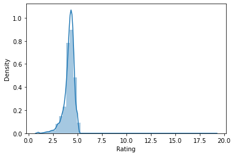

```python
#Check the distribution of rating column
sns.distplot(data['Rating'])
```

```python
#convert ratings into two categories and save it in the data frame as ‘Rating_cat’ ( high = +>3.5 and remaining as low)
data['Rating_cat']=['high' if x>=3.5 else 'low' for x in data['Rating'] ]
data.sample(5)
```

|  | App | Category | Rating | Reviews | Size | Installs | Type | Price | Content Rating | Genres | Last Updated | Current Ver | Android Ver | Rating_cat |
| --- | --- | --- | --- | --- | --- | --- | --- | --- | --- | --- | --- | --- | --- | --- |
| 2051 | Piano Kids - Music & Songs | FAMILY | 4.6 | 46741 | 50M | 10,000,000+ | Free | 0 | Everyone | Music;Music & Video | August 3, 2018 | 1.73 | 4.0.3 and up | high |
| 6510 | BN Pro PercentXL-b Neon HD Txt | LIBRARIES_AND_DEMO | 4.0 | 45 | 842k | 5,000+ | Free | 0 | Everyone | Libraries & Demo | February 5, 2017 | 2.3.2 | 1.6 and up | high |
| 2805 | Moony Lab - Print Photos, Books & Magnets ™ | PHOTOGRAPHY | 4.7 | 1320 | 9.5M | 50,000+ | Free | 0 | Everyone | Photography | June 27, 2018 | 2.1.9 | 4.1 and up | high |
| 7329 | Chrome Beta | PRODUCTIVITY | 4.4 | 228755 | Varies with device | 10,000,000+ | Free | 0 | Everyone | Productivity | July 19, 2018 | 68.0.3440.70 | Varies with device | high |
| 708 | Speed Reading | EDUCATION | 4.6 | 10611 | 11M | 500,000+ | Free | 0 | Everyone | Education | May 27, 2018 | 2.3.7 | 4.0 and up | high |

```python
#Convert the ‘Review’ column to a numerical column and impute invalid values if there are any

data = data.drop([10472])
```

```python
data['Reviews']=pd.to_numeric(data['Reviews'])
```

```python
#Name the top 5 apps which have the highest number of reviews and their genre
data.nlargest(5,'Reviews')
```

|  | App | Category | Rating | Reviews | Size | Installs | Type | Price | Content Rating | Genres | Last Updated | Current Ver | Android Ver | Rating_cat |
| --- | --- | --- | --- | --- | --- | --- | --- | --- | --- | --- | --- | --- | --- | --- |
| 3943 | Facebook | SOCIAL | 4.1 | 78128208 | Varies with device | 1,000,000,000+ | Free | 0 | Teen | Social | August 3, 2018 | Varies with device | Varies with device | high |
| 3904 | WhatsApp Messenger | COMMUNICATION | 4.4 | 69109672 | Varies with device | 1,000,000,000+ | Free | 0 | Everyone | Communication | August 3, 2018 | Varies with device | Varies with device | high |
| 3909 | Instagram | SOCIAL | 4.5 | 66509917 | Varies with device | 1,000,000,000+ | Free | 0 | Teen | Social | July 31, 2018 | Varies with device | Varies with device | high |
| 4104 | Messenger – Text and Video Chat for Free | COMMUNICATION | 4.0 | 56642847 | Varies with device | 1,000,000,000+ | Free | 0 | Everyone | Communication | August 1, 2018 | Varies with device | Varies with device | high |
| 3986 | Clash of Clans | FAMILY | 4.6 | 44881447 | 98M | 100,000,000+ | Free | 0 | Everyone 10+ | Strategy | July 15, 2018 | 10.322.16 | 4.1 and up | high |

```python
#Make the values of ‘Size’ as integers by replacing M and K with correct values.
#Convert all the values to numeric and make invalid values to NaN.
data['Size'].replace('Varies with device', np.NaN, inplace = True )
```

```python
data.Size = (data.Size.replace(r'[kM]+$', '', regex=True).astype(float) * \
             data.Size.str.extract(r'[\d\.]+([KM]+)', expand=False)
            .fillna(1)
            .replace(['k','M'], [10**3, 10**6]).astype(int))
```

```python
data["Size"].unique()
```

```
array([1.90e+07, 8.70e+06, 2.50e+07, 2.80e+06, 5.60e+06, 2.90e+07,
       3.30e+07, 3.10e+06, 2.80e+07, 1.20e+07, 2.00e+07, 2.10e+07,
       3.70e+07, 2.70e+06, 5.50e+06, 1.70e+07, 3.90e+07, 3.10e+07,
       1.40e+07, 4.20e+06, 2.30e+07, 6.00e+06, 6.10e+06, 4.60e+06,
       9.20e+06, 5.20e+06, 1.10e+07,      nan, 9.40e+06, 1.50e+07,
       1.00e+07, 1.20e+06, 2.40e+07, 2.60e+07, 8.00e+06, 7.90e+06,
       5.60e+07, 5.70e+07, 3.50e+07, 5.40e+07, 2.01e+02, 3.60e+06,
       5.70e+06, 8.60e+06, 2.40e+06, 2.70e+07, 2.50e+06, 7.00e+06,
       1.60e+07, 3.40e+06, 8.90e+06, 3.90e+06, 2.90e+06, 3.80e+07,
       3.20e+07, 5.40e+06, 1.80e+07, 1.10e+06, 2.20e+06, 4.50e+06,
       9.80e+06, 5.20e+07, 9.00e+06, 6.70e+06, 3.00e+07, 2.60e+06,
       7.10e+06, 3.70e+06, 2.20e+07, 7.40e+06, 6.40e+06, 3.20e+06,
       8.20e+06, 9.90e+06, 4.90e+06, 9.50e+06, 5.00e+06, 5.90e+06,
       1.30e+07, 7.30e+07, 6.80e+06, 3.50e+06, 4.00e+06, 2.30e+06,
       7.20e+06, 2.10e+06, 4.20e+07, 7.30e+06, 9.10e+06, 5.50e+07,
       2.30e+01, 6.50e+06, 1.50e+06, 7.50e+06, 4.60e+07, 5.10e+07,
       4.80e+07, 8.50e+06, 4.10e+07, 8.30e+06, 4.30e+06, 4.70e+06,
       3.30e+06, 4.00e+07, 7.80e+06, 8.80e+06, 6.60e+06, 5.10e+06,
       6.10e+07, 8.40e+06, 1.18e+02, 4.40e+07, 6.95e+02, 1.60e+06,
       1.80e+01, 5.30e+07, 6.20e+06, 3.00e+06, 5.80e+06, 3.80e+06,
       9.60e+06, 4.50e+07, 6.30e+07, 4.90e+07, 4.40e+06, 7.00e+07,
       6.90e+06, 9.30e+06, 8.10e+06, 4.80e+06, 3.60e+07, 7.70e+07,
       8.40e+07, 9.70e+07, 2.00e+06, 1.90e+06, 1.80e+06, 5.30e+06,
       4.70e+07, 5.56e+02, 5.26e+02, 7.60e+06, 7.60e+07, 9.70e+06,
       7.80e+07, 7.20e+07, 4.30e+07, 7.70e+06, 6.30e+06, 3.34e+02,
       1.40e+06, 3.40e+07, 9.30e+07, 6.50e+07, 1.00e+08, 5.00e+07,
       6.80e+07, 7.90e+07, 6.40e+07, 6.70e+07, 9.40e+07, 5.90e+07,
       6.00e+07, 5.80e+07, 2.32e+02, 9.90e+07, 6.24e+02, 9.50e+07,
       8.50e+00, 4.10e+01, 2.92e+02, 1.10e+01, 8.00e+07, 1.70e+06,
       6.90e+07, 7.10e+07, 6.20e+07, 9.80e+07, 8.50e+07, 8.60e+07,
       8.20e+07, 8.10e+07, 9.60e+07, 9.10e+07, 8.30e+07, 8.70e+07,
       6.60e+07, 7.50e+07, 9.20e+07, 8.62e+02, 8.99e+02, 3.78e+02,
       2.66e+02, 3.75e+02, 7.40e+07, 1.30e+06, 9.75e+02, 9.80e+02,
       4.10e+06, 8.90e+07, 8.80e+07, 6.96e+02, 5.44e+02, 5.25e+02,
       9.20e+02, 7.79e+02, 8.53e+02, 7.20e+02, 7.13e+02, 7.72e+02,
       3.18e+02, 5.80e+01, 2.41e+02, 1.96e+02, 8.57e+02, 5.10e+01,
       9.53e+02, 8.65e+02, 2.51e+02, 9.30e+02, 5.40e+02, 3.13e+02,
       7.46e+02, 2.03e+02, 2.60e+01, 3.14e+02, 7.90e+01, 2.39e+02,
       3.71e+02, 2.20e+02, 7.30e+02, 7.56e+02, 9.10e+01, 2.93e+02,
       1.70e+01, 7.40e+01, 1.40e+01, 3.17e+02, 7.80e+01, 9.24e+02,
```

[output cut: 22 more lines]

```
       6.01e+02, 2.21e+02, 2.28e+02, 1.08e+02, 9.40e+02, 1.76e+02,
       3.30e+01, 6.63e+02, 3.40e+01, 9.42e+02, 2.59e+02, 1.64e+02,
       4.58e+02, 2.45e+02, 6.29e+02, 2.80e+01, 2.88e+02, 7.75e+02,
       7.85e+02, 6.36e+02, 9.16e+02, 9.94e+02, 3.09e+02, 4.85e+02,
       9.14e+02, 9.03e+02, 6.08e+02, 5.00e+02, 5.40e+01, 5.62e+02,
       8.47e+02, 9.57e+02, 6.88e+02, 8.11e+02, 2.70e+02, 4.80e+01,
       3.29e+02, 5.23e+02, 9.21e+02, 8.74e+02, 9.81e+02, 7.84e+02,
       2.80e+02, 2.40e+01, 5.18e+02, 7.54e+02, 8.92e+02, 1.54e+02,
       8.60e+02, 3.64e+02, 3.87e+02, 6.26e+02, 1.61e+02, 8.79e+02,
       3.90e+01, 9.70e+02, 1.70e+02, 1.41e+02, 1.60e+02, 1.44e+02,
       1.43e+02, 1.90e+02, 3.76e+02, 1.93e+02, 2.46e+02, 7.30e+01,
       6.58e+02, 9.92e+02, 2.53e+02, 4.20e+02, 4.04e+02, 4.70e+02,
       2.26e+02, 2.40e+02, 8.90e+01, 2.34e+02, 2.57e+02, 8.61e+02,
       4.67e+02, 1.57e+02, 4.40e+01, 6.76e+02, 6.70e+01, 5.52e+02,
       8.85e+02, 1.02e+03, 5.82e+02, 6.19e+02])
```

```python
#Remove “,” and “+” from the values of the “Installs” column and change the datatype.
data.Installs = data.Installs.apply(lambda x: x.replace(',',''))
data.Installs = data.Installs.apply(lambda x: x.replace('+',''))
data.Installs = data.Installs.apply(lambda x: int(x))
```

```python
#What is the percentage of paid apps in the data
(data["Type"].value_counts()["Paid"]/data["Type"].shape[0])*100
```

```
7.806191117092867
```

```python
#Remove the “$” sign the “Price” column values and make it a numerical column.
data.Price.unique()
```

```
array(['0', '$4.99', '$3.99', '$1.49', '$2.99', '$7.99', '$3.49', '$1.99',
       '$5.99', '$6.99', '$9.99', '$7.49', '$0.99', '$1.00', '$2.49',
       '$10.99', '$1.50', '$14.99', '$15.99', '$79.99', '$9.00', '$10.00',
       '$16.99', '$11.99', '$29.99', '$74.99', '$5.49', '$33.99',
       '$24.99', '$39.99', '$19.99', '$4.49', '$1.70', '$8.99', '$2.00',
       '$3.88', '$25.99', '$399.99', '$17.99', '$400.00', '$3.02',
       '$1.76', '$4.84', '$4.77', '$1.61', '$2.50', '$1.59', '$6.49',
       '$1.29', '$5.00', '$13.99', '$299.99', '$379.99', '$37.99',
       '$18.99', '$389.99', '$19.90', '$8.49', '$1.75', '$14.00', '$4.85',
       '$46.99', '$109.99', '$3.95', '$154.99', '$3.08', '$2.59', '$4.80',
       '$1.96', '$19.40', '$3.90', '$4.59', '$15.46', '$3.04', '$12.99',
       '$4.29', '$2.60', '$3.28', '$4.60', '$28.99', '$2.95', '$2.90',
       '$1.97', '$200.00', '$89.99', '$2.56', '$30.99', '$3.61',
       '$394.99', '$1.26', '$1.20', '$1.04'], dtype=object)
```

```python
data["Price"] = data["Price"].apply(lambda x: x.replace('$',''))
data["Price"] = data["Price"].apply(lambda x: float(x))
```

```python
data.Price.unique()
```

```
array([  0.  ,   4.99,   3.99,   1.49,   2.99,   7.99,   3.49,   1.99,
         5.99,   6.99,   9.99,   7.49,   0.99,   1.  ,   2.49,  10.99,
         1.5 ,  14.99,  15.99,  79.99,   9.  ,  10.  ,  16.99,  11.99,
        29.99,  74.99,   5.49,  33.99,  24.99,  39.99,  19.99,   4.49,
         1.7 ,   8.99,   2.  ,   3.88,  25.99, 399.99,  17.99, 400.  ,
         3.02,   1.76,   4.84,   4.77,   1.61,   2.5 ,   1.59,   6.49,
         1.29,   5.  ,  13.99, 299.99, 379.99,  37.99,  18.99, 389.99,
        19.9 ,   8.49,   1.75,  14.  ,   4.85,  46.99, 109.99,   3.95,
       154.99,   3.08,   2.59,   4.8 ,   1.96,  19.4 ,   3.9 ,   4.59,
        15.46,   3.04,  12.99,   4.29,   2.6 ,   3.28,   4.6 ,  28.99,
         2.95,   2.9 ,   1.97, 200.  ,  89.99,   2.56,  30.99,   3.61,
       394.99,   1.26,   1.2 ,   1.04])
```

```python
# Which is the most expensive app and how much does it cost?
data.nlargest(1,'Price')
```

|  | App | Category | Rating | Reviews | Size | Installs | Type | Price | Content Rating | Genres | Last Updated | Current Ver | Android Ver | Rating_cat |
| --- | --- | --- | --- | --- | --- | --- | --- | --- | --- | --- | --- | --- | --- | --- |
| 4367 | I'm Rich - Trump Edition | LIFESTYLE | 3.6 | 275 | 7300000.0 | 10000 | Paid | 400.0 | Everyone | Lifestyle | May 3, 2018 | 1.0.1 | 4.1 and up | high |

```python
#Drop columns that you feel can not be used for model building.
data.drop(["App","Content Rating","Genres","Last Updated","Current Ver","Android Ver"],axis=1,inplace=True)
```

```python
data.info()
```

```
<class 'pandas.core.frame.DataFrame'>
Int64Index: 9659 entries, 0 to 10840
Data columns (total 8 columns):
 #   Column      Non-Null Count  Dtype
---  ------      --------------  -----
 0   Category    9659 non-null   object
 1   Rating      8196 non-null   float64
 2   Reviews     9659 non-null   int64
 3   Size        8432 non-null   float64
 4   Installs    9659 non-null   int64
 5   Type        9658 non-null   object
 6   Price       9659 non-null   float64
 7   Rating_cat  9659 non-null   object
dtypes: float64(3), int64(2), object(3)
memory usage: 679.1+ KB
```

```python
data['Size'] = data['Size'].fillna(data['Size'].mean())
data['Rating'] = data['Rating'].fillna(data['Rating'].median())
```

```python
data.info()
```

```
<class 'pandas.core.frame.DataFrame'>
Int64Index: 9659 entries, 0 to 10840
Data columns (total 8 columns):
 #   Column      Non-Null Count  Dtype
---  ------      --------------  -----
 0   Category    9659 non-null   object
 1   Rating      9659 non-null   float64
 2   Reviews     9659 non-null   int64
 3   Size        9659 non-null   float64
 4   Installs    9659 non-null   int64
 5   Type        9658 non-null   object
 6   Price       9659 non-null   float64
 7   Rating_cat  9659 non-null   object
dtypes: float64(3), int64(2), object(3)
memory usage: 679.1+ KB
```

```python
#Encode categorical column (Type, Rating_categories, Category)
data=pd.get_dummies(data,columns=["Category","Type","Rating_cat"])
data.head()
```

|  | Rating | Reviews | Size | Installs | Price | Category_ART_AND_DESIGN | Category_AUTO_AND_VEHICLES | Category_BEAUTY | Category_BOOKS_AND_REFERENCE | Category_BUSINESS | ... | Category_SOCIAL | Category_SPORTS | Category_TOOLS | Category_TRAVEL_AND_LOCAL | Category_VIDEO_PLAYERS | Category_WEATHER | Type_Free | Type_Paid | Rating_cat_high | Rating_cat_low |
| --- | --- | --- | --- | --- | --- | --- | --- | --- | --- | --- | --- | --- | --- | --- | --- | --- | --- | --- | --- | --- | --- |
| 0 | 4.1 | 159 | 19000000.0 | 10000 | 0.0 | 1 | 0 | 0 | 0 | 0 | ... | 0 | 0 | 0 | 0 | 0 | 0 | 1 | 0 | 1 | 0 |
| 2 | 4.7 | 87510 | 8700000.0 | 5000000 | 0.0 | 1 | 0 | 0 | 0 | 0 | ... | 0 | 0 | 0 | 0 | 0 | 0 | 1 | 0 | 1 | 0 |
| 3 | 4.5 | 215644 | 25000000.0 | 50000000 | 0.0 | 1 | 0 | 0 | 0 | 0 | ... | 0 | 0 | 0 | 0 | 0 | 0 | 1 | 0 | 1 | 0 |
| 4 | 4.3 | 967 | 2800000.0 | 100000 | 0.0 | 1 | 0 | 0 | 0 | 0 | ... | 0 | 0 | 0 | 0 | 0 | 0 | 1 | 0 | 1 | 0 |
| 5 | 4.4 | 167 | 5600000.0 | 50000 | 0.0 | 1 | 0 | 0 | 0 | 0 | ... | 0 | 0 | 0 | 0 | 0 | 0 | 1 | 0 | 1 | 0 |

5 rows × 42 columns

```python
data=data.drop(['Rating_cat_low'], axis=1)
```

## Prepare data for modeling

```python
#Segregate dependent variable and independent features into two separatevariables

x = data.iloc[:,1:-1].values
y = data.iloc[:,-1].values


#split the data into train and test set [ Use 70:30 split ]

from sklearn.model_selection import train_test_split
x_train, x_test, y_train, y_test = train_test_split(x, y, test_size = 0.3, random_state = 100)
```

## Build a classifier model to predict the rating category

```python
Result = pd.DataFrame(columns=['Model', 'accuracy', 'recall', 'precision', 'specificity', 'f1_score'])
from sklearn.metrics import confusion_matrix
from sklearn import metrics
def Model_statistics(model,y_test, y_pred):
    metric=pd.DataFrame(metrics.classification_report(y_test, y_pred,output_dict=True))
    accu=metric['accuracy'].values[0]
    preci=metric['weighted avg'].values[0]
    recall=metric['weighted avg'].values[1]
    f1_sc=metric['weighted avg'].values[2]
    tn, fp, fn, tp = confusion_matrix(y_test, y_pred).ravel()
    speci = tn / (tn+fp)
    Model_Stats=[[model,accu,recall,preci,speci,f1_sc]]
    return Model_Stats
```

## Decision Tree Classifier

```python
model='DecisionTree Classifier'
from sklearn.tree import DecisionTreeClassifier
classifier = DecisionTreeClassifier(criterion = 'entropy', random_state = 100)
classifier = classifier.fit(x_train, y_train)
y_pred = classifier.predict(x_test)

Result=Result.append(pd.DataFrame(Model_statistics(model,y_test, y_pred),columns=['Model', 'accuracy', 'recall', 'precision', 'specificity', 'f1_score']),ignore_index = True)
```

```python
pd.DataFrame(classifier.feature_importances_,index=data.columns[1:-1],columns=['Imp Features'])
```

|  | Imp Features |
| --- | --- |
| Reviews | 0.566679 |
| Size | 0.201433 |
| Installs | 0.052691 |
| Price | 0.014507 |
| Category_ART_AND_DESIGN | 0.001484 |
| Category_AUTO_AND_VEHICLES | 0.002604 |
| Category_BEAUTY | 0.001986 |
| Category_BOOKS_AND_REFERENCE | 0.006136 |
| Category_BUSINESS | 0.015148 |
| Category_COMICS | 0.002501 |
| Category_COMMUNICATION | 0.005564 |
| Category_DATING | 0.005705 |
| Category_EDUCATION | 0.001299 |
| Category_ENTERTAINMENT | 0.000000 |
| Category_EVENTS | 0.001307 |
| Category_FAMILY | 0.015778 |
| Category_FINANCE | 0.008805 |
| Category_FOOD_AND_DRINK | 0.003102 |
| Category_GAME | 0.003827 |
| Category_HEALTH_AND_FITNESS | 0.005696 |
| Category_HOUSE_AND_HOME | 0.002125 |
| Category_LIBRARIES_AND_DEMO | 0.003082 |
| Category_LIFESTYLE | 0.007745 |
| Category_MAPS_AND_NAVIGATION | 0.004428 |
| Category_MEDICAL | 0.007195 |
| Category_NEWS_AND_MAGAZINES | 0.005398 |
| Category_PARENTING | 0.001917 |
| Category_PERSONALIZATION | 0.003495 |
| Category_PHOTOGRAPHY | 0.002760 |
| Category_PRODUCTIVITY | 0.005637 |
| Category_SHOPPING | 0.003621 |
| Category_SOCIAL | 0.005231 |
| Category_SPORTS | 0.005932 |
| Category_TOOLS | 0.010220 |
| Category_TRAVEL_AND_LOCAL | 0.006371 |
| Category_VIDEO_PLAYERS | 0.003333 |
| Category_WEATHER | 0.000883 |
| Type_Free | 0.001693 |
| Type_Paid | 0.002683 |

b. Random Forest model

```python
model='RandomForest Classifier'
from sklearn.ensemble import RandomForestClassifier
classifier = RandomForestClassifier(criterion = 'entropy', random_state = 100)
classifier.fit(x_train, y_train)
y_pred = classifier.predict(x_test)
Result=Result.append(pd.DataFrame(Model_statistics(model,y_test, y_pred),columns=['Model', 'accuracy', 'recall', 'precision', 'specificity', 'f1_score']),ignore_index = True)
```

```python
pd.DataFrame(classifier.feature_importances_,index=data.columns[1:-1],columns=['Imp Features'])
```

|  | Imp Features |
| --- | --- |
| Reviews | 0.429941 |
| Size | 0.215490 |
| Installs | 0.195809 |
| Price | 0.012038 |
| Category_ART_AND_DESIGN | 0.001685 |
| Category_AUTO_AND_VEHICLES | 0.002855 |
| Category_BEAUTY | 0.001678 |
| Category_BOOKS_AND_REFERENCE | 0.004299 |
| Category_BUSINESS | 0.007295 |
| Category_COMICS | 0.002468 |
| Category_COMMUNICATION | 0.005105 |
| Category_DATING | 0.004763 |
| Category_EDUCATION | 0.002215 |
| Category_ENTERTAINMENT | 0.000820 |
| Category_EVENTS | 0.002245 |
| Category_FAMILY | 0.009973 |
| Category_FINANCE | 0.005503 |
| Category_FOOD_AND_DRINK | 0.002870 |
| Category_GAME | 0.007915 |
| Category_HEALTH_AND_FITNESS | 0.004848 |
| Category_HOUSE_AND_HOME | 0.001999 |
| Category_LIBRARIES_AND_DEMO | 0.002649 |
| Category_LIFESTYLE | 0.006512 |
| Category_MAPS_AND_NAVIGATION | 0.003622 |
| Category_MEDICAL | 0.006413 |
| Category_NEWS_AND_MAGAZINES | 0.004337 |
| Category_PARENTING | 0.001977 |
| Category_PERSONALIZATION | 0.005186 |
| Category_PHOTOGRAPHY | 0.005042 |
| Category_PRODUCTIVITY | 0.005551 |
| Category_SHOPPING | 0.003460 |
| Category_SOCIAL | 0.004319 |
| Category_SPORTS | 0.005912 |
| Category_TOOLS | 0.007408 |
| Category_TRAVEL_AND_LOCAL | 0.004892 |
| Category_VIDEO_PLAYERS | 0.003444 |
| Category_WEATHER | 0.000943 |
| Type_Free | 0.003180 |
| Type_Paid | 0.003341 |

c. Gradient Boosting model

```python
model='Gradient Boosting Classifier'
from sklearn.ensemble import GradientBoostingClassifier
gbcl = GradientBoostingClassifier(n_estimators = 50,random_state=100)
gbcl = gbcl.fit(x_train, y_train)
y_pred = gbcl.predict(x_test)
Result=Result.append(pd.DataFrame(Model_statistics(model,y_test, y_pred),columns=['Model', 'accuracy', 'recall', 'precision', 'specificity', 'f1_score']),ignore_index = True)
```

```python
pd.DataFrame(classifier.feature_importances_,index=data.columns[1:-1],columns=['Imp Features'])
```

|  | Imp Features |
| --- | --- |
| Reviews | 0.429941 |
| Size | 0.215490 |
| Installs | 0.195809 |
| Price | 0.012038 |
| Category_ART_AND_DESIGN | 0.001685 |
| Category_AUTO_AND_VEHICLES | 0.002855 |
| Category_BEAUTY | 0.001678 |
| Category_BOOKS_AND_REFERENCE | 0.004299 |
| Category_BUSINESS | 0.007295 |
| Category_COMICS | 0.002468 |
| Category_COMMUNICATION | 0.005105 |
| Category_DATING | 0.004763 |
| Category_EDUCATION | 0.002215 |
| Category_ENTERTAINMENT | 0.000820 |
| Category_EVENTS | 0.002245 |
| Category_FAMILY | 0.009973 |
| Category_FINANCE | 0.005503 |
| Category_FOOD_AND_DRINK | 0.002870 |
| Category_GAME | 0.007915 |
| Category_HEALTH_AND_FITNESS | 0.004848 |
| Category_HOUSE_AND_HOME | 0.001999 |
| Category_LIBRARIES_AND_DEMO | 0.002649 |
| Category_LIFESTYLE | 0.006512 |
| Category_MAPS_AND_NAVIGATION | 0.003622 |
| Category_MEDICAL | 0.006413 |
| Category_NEWS_AND_MAGAZINES | 0.004337 |
| Category_PARENTING | 0.001977 |
| Category_PERSONALIZATION | 0.005186 |
| Category_PHOTOGRAPHY | 0.005042 |
| Category_PRODUCTIVITY | 0.005551 |
| Category_SHOPPING | 0.003460 |
| Category_SOCIAL | 0.004319 |
| Category_SPORTS | 0.005912 |
| Category_TOOLS | 0.007408 |
| Category_TRAVEL_AND_LOCAL | 0.004892 |
| Category_VIDEO_PLAYERS | 0.003444 |
| Category_WEATHER | 0.000943 |
| Type_Free | 0.003180 |
| Type_Paid | 0.003341 |

## Stacking model

```python
model='Stacking Classifier'
from sklearn.ensemble import StackingClassifier
from sklearn.linear_model import LogisticRegression
from sklearn.neighbors import KNeighborsClassifier
base_learners = [
                 ('rf_1', RandomForestClassifier(n_estimators=10, random_state=100)),
                 ('rf_2', KNeighborsClassifier(n_neighbors=5))
                ]
classifier = StackingClassifier(estimators= base_learners, final_estimator=LogisticRegression())
classifier.fit(x_train, y_train)
y_pred = classifier.predict(x_test)
Result=Result.append(pd.DataFrame(Model_statistics(model,y_test, y_pred),columns=['Model', 'accuracy', 'recall', 'precision', 'specificity', 'f1_score']),ignore_index = True)
```

```python
Result
```

|  | Model | accuracy | recall | precision | specificity | f1_score |
| --- | --- | --- | --- | --- | --- | --- |
| 0 | DecisionTree Classifier | 0.822291 | 0.822291 | 0.825694 | 0.623437 | 0.82387 |
| 1 | RandomForest Classifier | 0.862319 | 0.862319 | 0.856227 | 0.60625 | 0.857731 |
| 2 | Gradient Boosting Classifier | 0.873361 | 0.873361 | 0.869446 | 0.535937 | 0.862741 |
| 3 | Stacking Classifier | 0.861629 | 0.861629 | 0.854164 | 0.560937 | 0.854056 |